# Part II - Ford GoBike System Data

## by Waad AlDoaij

## Investigation Overview

> I came to some conclusions following the visualization and exploration. I discovered that men make up the majority of users, whether they are customers or subscribers, and that the Subscriber client was higher than the customer client,The majority of people who use bikes are between the ages of 20 and 40, and they are likely to dislike sharing them. I also learned that the most frequent starting and ending times are usually on weekdays rather than weekends, from seven in the morning until nine in the morning, and from four in the afternoon until six in the evening. I might say that there are some issues that I need to fix on and such as some erroneous data types and some missing values.

> **Key Insights for Presentation:**
> 1. Bikes are most commonly used by individuals between the ages of 20 and 40.
> 2. The majority of the user member were men who had huge gab with other users.
> 3. increasing bike use between 7~9 in the morning and 4~6 in the evening.

## Dataset Overview

> This data set which contains details about each trip taken in a bike-sharing program serving the greater San Francisco Bay area, will be used in this study, these dataframe following columns are: (duration_sec, start_time, starting_Day, end_time, ending_Day, start_station_id, start_station_name, start_station_latitude,start_station_longitude, end_station_id, end_station_name,end_station_latitude, end_station_longitude, bike_id, user_type,member_birth_year, member_gender, bike_share_for_all_trip,Hours)

## 1.Common Gender Riders

> The pie-chart below shows the gender of members, which are male with %,74.59 female %23.32 and others %2.08, as I indicated the male user is the most frequent user to ride the bike. We can also see a large gap with the other gender.

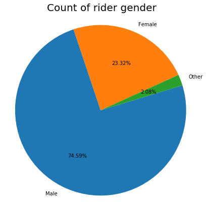

```python
figz(19,7)
member_count = df['member_gender'].value_counts()

plt.pie(member_count  , labels = member_count.index ,startangle = 17, counterclock = False, autopct='%1.2f%%');
plt.axis('square')
plt.title('Count of rider gender', fontsize= 20);
```

## 2.Distribution of Bike Usage Per Hour

> According to the graph below, there will be an increase in use between 7 and 9 a.m. and 4 to 6 p.m. I believe it is because of their daily journey to go and back from work.

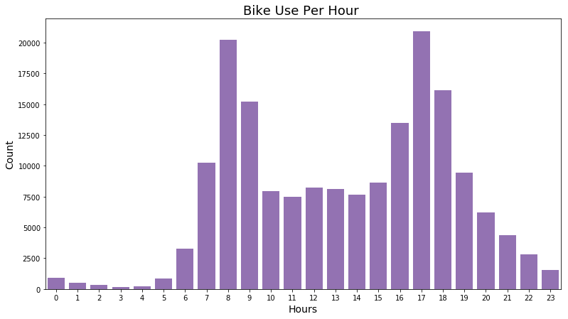

```python
figz(13,7)
p = sb.color_palette()[4]
sb.countplot(data = df, x = 'Hours', color = p )

functionN('Hours', 'Count','Bike Use Per Hour ')
```

## 3. User Gender Based On Ages

The chart below shows that all gender members are increasing, particularly between the ages of 20 and 40.

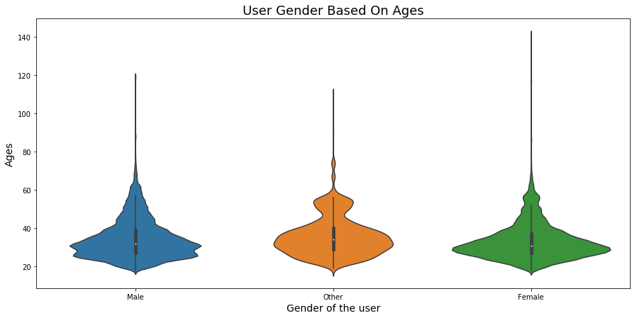

```python
figz(15,7)

sb.violinplot(data=df,x='member_gender',y= ages )

functionN('Gender of the user', 'Ages','User Gender Based On Ages')
```